# COMP60711 - Part 2 Coursework 2

| Course Unit: | COMP60711: Data Engineering |
| --- | --- |
| Responsible Staff Member: | Professor John Keane |
| Marks: | This course is worth **25%** of the overall marks for this unit. |
| Submissions: | This is the **4th** of **4** assessed submissions. |
| Method of Submitting: | This notebook, after completion, should be saved as a HTML document and submitted using Blackboard |
| Deadline: | Thursday 4th November 9AM (UK time) |
| Late Submissions: | Extensions will only be granted as a result of formally processed [Mitigating Circumstances](http://documents.manchester.ac.uk/DocuInfo.aspx?DocID=427). Marks for late submissions will be reduced in l… |

Please complete the questions in the spaces provided (under the "Answer" block for each question), then download the notebook in HTML format and submit to Blackboard.

Please also add your student ID and name below.

| Student ID (7-8 digit number) | Full Name |
| --- | --- |
| 10844274 | Hao Li |

## Reminders

- **Please make clear any assumptions and provide evidence to justify your answers**
- Jupyter notebooks use markdown. A brief summary of how to use markdown can be seen [here](https://github.com/adam-p/markdown-here/wiki/Markdown-Cheatsheet). Otherwise, please refer to the brief guide on Blackboard.
- You **must** cite any sources used, from web pages to academic papers and textbooks.
- Please ensure your code has no errors, and that the output is shown in your submitted version.
- We have added some general notebooks on Blackboard to cover the basics of plotting in Python, Jupyter notebooks, and anaconda.
- Some questions require a mixture of code and text to answer the question. Marks are awarded based on the output of your code (i.e. graphs) and the explanation provided, not on the code itself.

# Q1: Pre-processing & Feature Importance (9 marks)

This question will use the `"genes-leukemia.csv"` dataset available on Blackboard. For some background information about this dataset, see https://www.kdnuggets.com/data_mining_course/data/genes-leukemia-description.txt. The sub-questions will involve inspecting and pre-processing the data in order to use a decision tree. We will then look at which features are deemed important for prediction, and how removing important features affects tree structure.

It is expected that you will use `pandas` for this question, though this is not a requirement (but it may be more difficult if you do not).

## Q1.1 (1 mark)

Count the number of records/examples where the "Treatment_Response" feature is non-missing. Describe these examples in terms of the other features (Year from XXXX to YYYY, Gender = X etc.)

**Hint:**

- You need to ensure that you are looking at all of the data. By default, some of the columns may be truncated, in which case you should adjust this (through e.g. `pd.set_option("display.max_columns", 100)`)

## Q1.1 Answer

```python
import pandas as pd
pd.set_option("display.max_columns", 100)
list1 = pd.read_csv("genes-leukemia.csv")
#print(list1['Treatment_Response'].count())
list2 = pd.read_csv("genes-leukemia.csv")['Treatment_Response']
non_missing_record = list1.loc[(list1['Treatment_Response'] == 'Failure') | (list1['Treatment_Response'] == 'Success')]
print(non_missing_record)
```

```
   SNUM CLASS BM_PB TB_if_ALL FAB_if_AML Year Gender pct_Blasts  \
27  s28   AML    BM         ?         M2    ?      ?         79
28  s29   AML    BM         ?         M2    ?      ?         34
29  s30   AML    BM         ?         M5    ?      ?         93
30  s31   AML    BM         ?         M4    ?      ?         77
31  s32   AML    BM         ?         M1    ?      ?         86
32  s33   AML    BM         ?         M2    ?      ?         70
33  s34   AML    BM         ?         M2    ?      ?         77
34  s35   AML    BM         ?         M1    ?      ?         67
35  s36   AML    BM         ?         M5    ?      ?         76
36  s37   AML    BM         ?         M2    ?      ?         44
37  s38   AML    BM         ?         M1    ?      ?         80
49  s50   AML    BM         ?         M4    ?      ?         93
50  s51   AML    BM         ?         M2    ?      ?         57
51  s52   AML    PB         ?         M4    ?      ?         86
```

[output cut: 103 more lines]

The number of records/examples where the "Treatment_Response" feature is non-missing is:

```python
print(len(non_missing_record))
```

```
15
```

From these examples, "Year", "Gender" and "TB_if_ALL" values are missing for all records.All records has "AML" as CLASS and "CALGB" as Source. For feature "X52142", most records have "20" as the value in this column. Only two records with failure treatment have "41" and "201" in this column. For feature "L13278", all of succesful treatment has 20 or 22 as the value in this column. For "feature"U53468", exclude s53, all successful treatment has 20 as the values.

## Q1.2 (1 mark)

Explain why it is not correct to build predictive models for "Treatment_Response" using records where it is missing?

## Q1.2 Answer

‍The missing data is a challenging part to build predictive models. The missing value will potentially cause the inaccurate decisions in the modeling phase [1]. Therefore, when we build predictive models, it needs to do some pre-processing to handle missing values to avoid misleading predictions from the missing value [2]. Therefore, build predictive models with missing the "Treatment_Response" record is not a sensible approach. It increases the possibility of the model making the wrong decisions.

### From Q1.3-Q1.6 (inclusive), use only the subset of data where "Treatment_Response" is non-missing.

## Q1.3 (1 mark)

Remove the features that are either all the same or have all missing values. Which sample fields should you keep?

**Hints:**

- For simplicity in the following questions, also remove "FAB_if_AML".
- "SNUM" should be the index.

## Q1.3 Answer

In this quesiton ,we will remove all features that either all the same or have all missing values. At the same time, column"SNUM" should be index and "FAB_if_AML" will be removed. Furthermore, there is another column that needs to consider further which is "BM_PB". We will consider the usefulness of a features from an information gain perspective. This column contains mostly (all but one) the same value. Only s52 shows "PB" in this column, and other records contain the same value "BM". Generally, the feature that contains more values will provide more information to the model predicting [3]. Since from information gain perspective, this feature that contains mostly the same value would not perform well. Therefore, we decide to remove this column in Question 1.3 and it is seen as one step of pre-processing.

```python
# Remove the  "FAB_if_AML".nunique_value
remove_fab = non_missing_record.drop(columns=['FAB_if_AML'])
remove_BMPB = remove_fab.drop(columns=['BM_PB'])

# Remove the same or have all missing values
nunique_value = non_missing_record.nunique()
removed_same_value = nunique_value[nunique_value == 1].index

q13_Result = remove_BMPB.drop(removed_same_value, axis=1)
q13_Result.set_index('SNUM', inplace=True)
print(q13_Result)
```

```
     pct_Blasts Treatment_Response    PS  D49950  D63880  J03473  J05243  \
SNUM
s28          79            Failure  0.44     297     279     841     102
s29          34            Failure  0.74     190     277     500     237
s30          93            Failure  0.80     326     136     426     238
s31          77            Failure  0.61     197     321     871      57
s32          86            Failure  0.47     259     283     671     628
s33          70            Failure  0.89     100     151     109      20
s34          77            Success  0.64     355     226     803     206
s35          67            Success  0.21     295      20     430      20
s36          76            Success  0.94     283     410     603      20
s37          44            Success  0.95     311     185     404      87
s38          80            Success  0.73      70     118     355      71
s50          93            Failure  0.97     346     164     675     135
s51          57            Failure  1.00     211     209     506      48
s52          86            Success  0.61     109     131     488     294
s53          76            Success  0.89     106      94     449     109

      L13278  L47738  M21551_rna1  M55150  M62762  M81933  M91432  S50223  \
SNUM
s28       20     449          456    1929    2702     313     323     107
s29       20      65          259    1647    1736     243     125     150
s30       20     172          487    2112    3553     229     158      20
s31       60     239          554    1555    3255     132     295      31
s32       34     683          462    1514    4249     230     368     210
s33       20     153          672    2693    1871     282     110      20
s34       20      20          405    1811    3236     179     263      56
s35       20     218          327    1406    1125     214     226     168
s36       22      20          485    1707    4647     179      87      20
s37       20      20          415    2072    3808     330     183      20
s38       20     201          582    1753    3594     407     111      62
s50       38     578          342    1895    3427     274     225      48
s51       20     446          339    1339    2120      20     126      20
s52       20     455          354     801    3266      62     163      20
s53       20     118          308    1534    3457     206     135      45

      U12471_cds1  U32944  U35451  U50136_rna1  U53468  U72342  U82759  \
SNUM
s28           238     384     209         1641      20      32     822
s29           217     179      29         2545      31     173    1137
```

[output cut: 52 more lines]

```
s28         91       151        20     353      20     429
s29         58        66        20     279      35     314
s30         20        20        60     250      20     208
s31         61        20        56     381      20     385
s32         50       192        88     671      20     688
s33         20        20        20     200      20     248
s34         34       282        20     299      20     454
s35         48        43        38     389      67     391
s36         74        64        20     126      20     412
s37         52        20        93     190      20     393
s38         33        20        20     275      20     286
s50         45        20        48     197     110     190
s51         50        20        52     110      44     382
s52         20       376        25     139      20     250
s53         20       119        39     388      20     367
```

## Q1.4 (1 mark)

Fit a decision tree (`DecisionTreeClassifier`) using default settings to the data, now that it has been pre-processed.

As we have a small amount of data, if we want to more meaningfully assess the performance, we should use leave-one-out cross-validation. Report the accuracy across each fold, and the overall mean accuracy obtained.

Important: Please use `random_state=42` where necessary to ensure reproducible results.

## Q1.4 Answer

```python
from sklearn.model_selection import cross_val_score
from sklearn.tree import DecisionTreeClassifier
from sklearn.model_selection import LeaveOneOut
from sklearn.model_selection import train_test_split
from sklearn import metrics
clf = DecisionTreeClassifier(random_state=42)
loo = LeaveOneOut()
list_y = []
for data in non_missing_record['Treatment_Response']:
    list_y.append(data)
TR_to_int = q13_Result.drop(columns=['Treatment_Response'])
q14_score = []
q14_acc = []
for train, test in loo.split(TR_to_int):
    list_testY = []
    x_train = TR_to_int.drop(TR_to_int.index[test])
    x_test = TR_to_int.iloc[[int(test)]]
    y_train = list_y[:int(test)] + list_y[int(test)+1 :]
    y_test = list_y[int(test)]
    clf14 = clf.fit(x_train,y_train)
    y_pred=clf.predict(x_test)
    list_testY.append(y_test)
    score = metrics.accuracy_score(list_testY,y_pred)
    q14_acc.append(score)
    q14_score.append("Accuracy of fold " + str(test[0]) + " : " + str(score))
print(q14_score)
mean_acc = sum(q14_acc)/len(q14_acc)
print("The overall mean accuracy obtained is:")
print(mean_acc)
```

```
['Accuracy of fold 0 : 1.0', 'Accuracy of fold 1 : 1.0', 'Accuracy of fold 2 : 1.0', 'Accuracy of fold 3 : 1.0', 'Accuracy of fold 4 : 1.0', 'Accuracy of fold 5 : 1.0', 'Accuracy of fold 6 : 1.0', 'Accuracy of fold 7 : 1.0', 'Accuracy of fold 8 : 1.0', 'Accuracy of fold 9 : 0.0', 'Accuracy of fold 1…
The overall mean accuracy obtained is:
0.8666666666666667
```

## Q1.5 (3 marks)

Split the data into a training and test set (using a 75:25 ratio). Once again, fit a decision tree to this data, and report the accuracy. Visualize the tree (using `tree.plot_tree`), and state which feature/predictor is the most important. Then, removing this top predictor, fit the tree again with this feature removed. Again, report the accuracy and visualize the tree.

Compare the accuracy between the two trees. Explain why the tree is different with this feature removed.

Important: Please use `random_state=3` where necessary to ensure reproducible results.

**Hint:**

- You need to ensure that the *original* feature names are visible in the tree.

## Q1.5 Answer

```
The accuracy is :
0.75
```

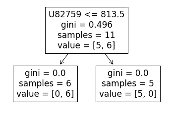

```python
from sklearn import tree
from sklearn.model_selection import train_test_split
#df = pd.DataFrame(q13_result, columns=q13_result.feature_names)
X_train, X_test, Y_train, Y_test = train_test_split(TR_to_int, list_y,  test_size=0.25, random_state=3)
clf_15 = tree.DecisionTreeClassifier(random_state=3)
clf15 = clf_15.fit(X_train, Y_train)
y_pred=clf15.predict(X_test)
score_q15 = metrics.accuracy_score(Y_test,y_pred)
print("The accuracy is :")
print(score_q15)
feature_name = list(TR_to_int.columns.values)
tree.plot_tree(clf15,feature_names=feature_name);
```

```python
# Get the most important feature
importance = clf15.feature_importances_
importance_list = list(importance)
most_important_feature = importance_list.index(max(importance_list))
print(feature_name[most_important_feature])
```

```
U82759
```

```
The accuracy is :
0.5
```

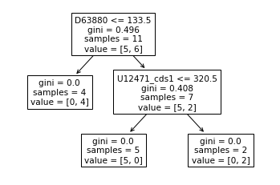

```python
Q15_remove_top = TR_to_int.drop(columns=['U82759'])
X_train2, X_test2, Y_train2, Y_test2 = train_test_split(Q15_remove_top, list_y,  test_size=0.25, random_state=3)
clf_15_2 =  tree.DecisionTreeClassifier(random_state=3)
clf15_2 = clf_15_2.fit(X_train2, Y_train2)
Y_pred2=clf15_2.predict(X_test2)
score_q15_2 = metrics.accuracy_score(Y_test2,Y_pred2)
print("The accuracy is :")
print(score_q15_2)
feature_name = list(Q15_remove_top.columns.values)
tree.plot_tree(clf15_2,feature_names=feature_name);
```

The first tree has higher accuracy which is 0.75. The sklearn provided a feature*importances* function to return the feature importances [4]. The importance of a feature means the total reduction of criterion brought by the feature [4].We used this function to get the most important feature. For the first tree, the most important feature is "U82759". Then we remove this top predictor to fit the second tree. The accuracy of the second tree is 0.5. Szczerbicki states for decision tree classifiers, the most important feature is the capability of capturing descriptive decision-making knowledge from the supplied data [5]. Therefore, removing the most important feature, then accuracy for decision tree classifiers decreases is a reasonable result.

Another difference between the first tree and the second tree is the depth of the tree. The depth of the tree indicates the times of tree needs to splits before the prediction [6]. Since the most important feature was removed, the second tree is getter hard to capture descriptive decision-making knowledge from the supplied data than first tree. Therefore, it requires more times to split until pure.

## Q1.6 (2 marks)

Which tree do you think is more generalizable? You may want to more thoroughly compare the trees (readability, sensitivity/specificity, structure simplicity, etc.).

## Q1.6 Answer

The first tree is more generalizable. For the readability side, the depth of this tree is less than the second tree. For the sensitivity/specificity side, the accuracy of the first tree shows a higher score than the second tree. Therefore, the first tree also shows performed better in this side. Some people believe that tree simplicity means the number of leaves or rules in the Decision Tree Classifier [7]. The first tree has fewer leaves than the second tree. Therefore, the first tree has a more simple structure than the second tree.

# Q2: Decision Boundaries (4 marks)

In this question, we will visualize the decision boundaries formed by three simple classifiers on an example dataset.

## Q2.1 (4 marks)

We have provided code below to produce the data and to create the decision boundary. You will need to run this code using the following models:

1. "ZeroR" classifier - `sklearn.dummy.DummyClassifier` using the `"most_frequent"` strategy.
2. KNN classifier - `sklearn.neighbors.KNeighborsClassifier`
3. Decision tree classifier - `sklearn.tree.DecisionTreeClassifier`

You will need to modify the code to output the accuracy for each of the models. Using both this information and the visualized decision boundaries, explain the performance of these algorithms. A brief explanation of the classifiers will be required for this.

**Hints:**

- Although not necessary, the use of further visualizations, performance measures, or even datasets may help to support your discussion
- Use the decision boundaries as a reference point to explain the **differences** between the classifiers.

### Notice:

Due to the provided function :get_data() function randomly generates data with two features which means the features do not have names. It makes it hard to show as axis name clearly in the graph. Since it only contains two features, we will name that first feature called "feature1" and second feature called "feature2" to make it clear in the output graph.

```python
'''
The code below provides you with the functions to get the data,
and plot the decision boundary.

The resulting graphs have not been properly formatted, however,
so you will need to add that. You will also need to modify the
code to output the accuracy.
'''

import numpy as np
from sklearn.datasets import make_classification

def get_data():
    # Create data
    data, labels = make_classification(
        n_features=2, n_redundant=0, n_informative=2,
        random_state=1, n_clusters_per_class=1
    )
    # Set the RNG
    rng = np.random.RandomState(42)
    # Add some noise
    data += 2 * rng.uniform(size=data.shape)
    return data, labels

def plot_boundary(X, ax, clf):
    # Plotting decision regions
    x_min, x_max = X[:, 0].min() - 1, X[:, 0].max() + 1
    y_min, y_max = X[:, 1].min() - 1, X[:, 1].max() + 1
    xx, yy = np.meshgrid(
        np.arange(x_min, x_max, 0.1),
        np.arange(y_min, y_max, 0.1)
    )
    Z = clf.predict(np.c_[xx.ravel(), yy.ravel()])
    Z = Z.reshape(xx.shape)
    ax.contourf(xx, yy, Z, alpha=0.4)
    return ax

def boundary_full(data, labels, model, name, **kwargs):
    # Create estimator/model/classifier
    clf = model(**kwargs)
    # Fit the classifier
    clf.fit(data, labels)

    # Create axis
    fig, ax = plt.subplots()
    # Call the provided function
    ax = plot_boundary(data, ax, clf)
    # Now add the data (using scatter)
    # Ensure to colour the points according to the prediction
    ax.scatter(data[:,0], data[:,1], c=labels, s=20, edgecolor="k")
    # Format the graph...
    # Output as score.
    plt.title(name)
    plt.xlabel("feature 1")
    plt.ylabel("feature 2")
    print(clf.score(data, labels))
```

## Q2.1 Answer

```python
from sklearn.dummy import DummyClassifier
from sklearn.neighbors import KNeighborsClassifier
from matplotlib import pyplot as plt
data_q21 = get_data()[0]
label_q21 = get_data()[1]
```

```
0.5
```

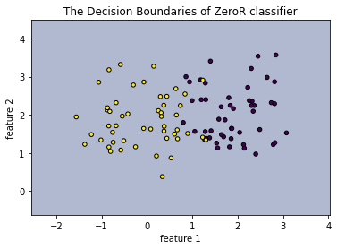

```python
boundary_full(data_q21,label_q21,DummyClassifier,"The Decision Boundaries of ZeroR classifier",strategy="most_frequent")
```

```
0.96
```

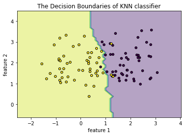

```python
boundary_full(data_q21,label_q21,KNeighborsClassifier,"The Decision Boundaries of KNN classifier")
```

```
1.0
```

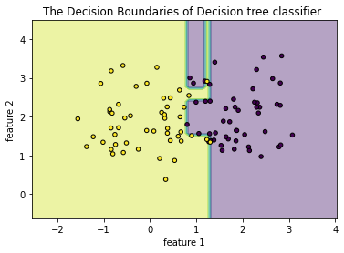

```python
boundary_full(data_q21,label_q21,DecisionTreeClassifier,"The Decision Boundaries of Decision tree classifier ")
```

### The performance of these three algorithm

The zeroR is the simplest classification algorithm [8]. It relies on the target and will ignore all predictors. It will create a table with frequency for the target and select its most frequent value. Therefore, this algorithm is only able to predict the majority category. It makes the decision boundaries does not worked in this algorithm. In our experiment, the accuracy of this algorithm is only 0.5. However, considering how this algorithm works, this accuracy is a reasonable value.

The Knn algorithm is a simple Machine Learning algorithms [9]. Firstly, this algorithm will select k number of neighbors. Then calculate the Euclidean distance of k number of neighbors. Thirdly, taking k nearest neighbors by Euclidean distance. Then in these k neighbors, count the number of the data in each category. Finally, assign new data to the category in which the number of the neighbor reaches the maximum value. The advantage of this algorithm is it is able to handle noisy data and performed well in large size of data [9].

Therefore, it makes the decision boundaries of KNN show problem as "The Decision Boundaries of KNN classifier" graph before. For each region, due to it calculates the Euclidean distance of k number of neighbors. It makes each region is only able to show single color. Choose a high-value k will generate more voters in each prediction to solve this problem [10]. However, in this part, we used the default setting with k =5. Therefore, some points will not able to be located in the correct region. In the graph, one black point is in the yellow area and some yellow points are in the dark area. It caused by the distance of these points is not far enough to generate k-neighbors. It makes them in the wrong location and causes accuracy is 0.96.

The Decision Tree Classifier algorithm shows the best performance in these three algorithms. The accuracy is 1.0 and all points are located in the correct region. This algorithm performed well for solving decision-related problems [11]. At the same time, due to the feature of this dataset is simple. It would not cause an over-fitting problem for the Decision Tree Classifier algorithm. These points make Decision Tree Classifier is a sensible approach for working on this dataset.

# Question 3: Training Time Comparison (4 marks)

## Q3.1 (2 marks)

Plot the training time for both `DecisionTreeClassifier` and `GaussianNB` against the data size. A function to generate the data is provided to you, which takes the size as its only argument.

Explain what you observe and your understanding in terms of training time and data size (include a graph). Consider algorithm implementation and potential stochasticity in running times.

```python
# Use this function to measure the time
from time import time

# Use this function to generate the data
def create_data(size):
    # Create data
    data, labels = make_classification(
        n_samples=size,
        n_features=2, n_redundant=0, n_informative=2,
        random_state=4, n_clusters_per_class=1
    )
    return data, labels
```

## Q3.1 Answer

```
[0.0009968280792236328, 0.0009913444519042969, 0.000985860824584961, 0.0010004043579101562, 0.001990795135498047, 0.002969026565551758, 0.005984067916870117, 0.01495981216430664]
[0.000997304916381836, 0.0, 0.003989219665527344, 0.006981372833251953, 0.030916690826416016, 0.04990649223327637, 0.18849444389343262, 0.44187259674072266]
```

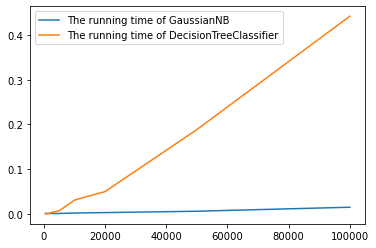

```python
from sklearn.naive_bayes import GaussianNB
import time
q_31_size_list = [500,1000,3000,5000,10000,20000,50000,100000]
running_time_GNB = []
running_time_DTC = []
clf_1 = GaussianNB()
clf_2 = DecisionTreeClassifier()
for data in q_31_size_list:
    train_x = create_data(data)[0]
    train_y = create_data(data)[1]
    start_time = time.time()
    clf_1.fit(train_x,train_y)
    running_time_GNB.append((time.time() - start_time))
for data in q_31_size_list:
    train_x = create_data(data)[0]
    train_y = create_data(data)[1]
    start_time = time.time()
    clf_2.fit(train_x,train_y)
    running_time_DTC.append((time.time() - start_time))
print(running_time_GNB)
print(running_time_DTC)

plt.plot(q_31_size_list, running_time_GNB, label = "The running time of GaussianNB", linestyle="-")
plt.plot(q_31_size_list, running_time_DTC, label = "The running time of DecisionTreeClassifier", linestyle="-")
plt.legend()
plt.show()
```

Due to in this graph, the change of running time of Gaussian NB is not clear enough to make it hard to measure. There is another graph that contains Gaussian NB only.

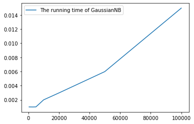

```python
plt.plot(q_31_size_list, running_time_GNB, label = "The running time of GaussianNB", linestyle="-")
plt.legend()
plt.show()
```

These two graphs clearly show the running time increase with the dataset size increase for both algorithms. On the running time side, the GaussianNB algorithm shows better performance than the Decision Tree Classifier for the same size of data. Naive Bayes Classifier is a sensible approach to working on a dataset with large data and few features [12]. The Naive Bayes has a list of probabilities with class probabilities and conditional probabilities for training [13]. Since it only calculates the probability of each class and the probability of each class given different input (x) values without any optimization procedures [13]. Therefore, it would not consider about the potential stochasticity problem. These points make the running speed of Naive Bayes will be very fast. However, the Decision tree algorithm needs to find the best split for each possible feature [11]. This split stage will causes potential stochasticity problems. Therefore, Decision tree algorithm will spend much more time than Naive Bayes and causes potential stochasticity problems in the training stage.

## Q3.2 (2 marks)

What do you think would happen if we continue increasing the number of instances? Which of the algorithms would be more suitable for a very large number of instances and why? Consider the algorithms’ complexity and how they scale.

## Q3.2 Answer

The Naive Bayes is a better approach for working with a very large number of data.

The running time of Naive Bayes is :

O(d*c)

d is the query vector’s dimension and c is the total class [14].

The running time of Decision tree is :

O(n *m* logn) [4]

where n is the number of sample, m is the number of features.

Therefore, it is clear Naive Bayes performed better on the training time side. If the number of instances increases, The GaussianNB will still have the advantage for running time.

# Question 4: Memory Usage Comparison (3 marks)

# Q4.1 (3 marks)

Plot the memory usage of the `DecisionTree` model against the data size. Explain the memory usage of the model (including a graph in your answer).

You should use the same `create_data()` function provided for Q3, and ensure that you have downloaded `memory.py` from Blackboard in order to load the `measure_memory()` function.

```python
from memory import measure_memory
```

## Q4.1 Answer

```python
clf_41 = DecisionTreeClassifier()
memory_list = []
for data in q_31_size_list:
    train_x = create_data(data)[0]
    train_y = create_data(data)[1]
    memory_list.append(measure_memory(train_x,train_y,clf_41))
print(q_31_size_list)
print(memory_list)
```

```
[500, 1000, 3000, 5000, 10000, 20000, 50000, 100000]
[148.88671875, 148.890625, 149.0234375, 149.21875, 150.12109375, 150.421875, 154.60546875, 156.16796875]
```

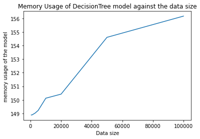

```python
plt.xlabel("Data size")
plt.ylabel("memory usage of the model ")
plt.title("Memory Usage of DecisionTree model against the data size")
plt.plot(q_31_size_list, memory_list)
plt.show()
```

From graph "Memory Usage of Decision Tree model against the data size", it clearly shows the memory usage of decision tree model has positive relationship to data size. A large size of data will spend more memory usage for the decision tree algorithm. Another point which worth to notice is the feature of this data set is very simple. Some research states that more class label will incresase the computational complexity of the decision tree [11]. Moreover, the default values of decision tree will leads hugh memory consumption on some datasets [4]. Therefore, from memory usage side, the Decision Tree may not be the best choice. It needs to consider further with the data structure of the working dataset.

# Reference:

[1] Predictive Modeling, [Online], Available from : https://www.omnisci.com/technical-glossary/predictive-modeling [Accessed 4/11/20201]

[2] N.Sharma, Data Pre-processing and Visualization for Machine Learning Models,[Online], Available from : https://heartbeat.comet.ml/data-preprocessing-and-visualization-implications-for-your-machine-learning-model-8dfbaaa51423 [Accessed 4/11/20201]

[3] Information Gain, [Online], Available from : https://homes.cs.washington.edu/~shapiro/EE596/notes/InfoGain.pdf [Accessed 4/11/20201]

[4] sklearn.tree.DecisionTreeClassifier, scikit-learn, [Online], Available from : https://scikit-learn.org/stable/modules/generated/sklearn.tree.DecisionTreeClassifier.html [Accessed 4/11/20201]

[5] E. Szczerbicki, Management of Complexity and Information Flow, [Online],Available from : https://www.sciencedirect.com/topics/computer-science/decision-tree-classifier [Accessed 4/11/20201]

[6] M.Galarnyk, Understanding Decision Trees for Classification (Python) , [Online], Available from : https://towardsdatascience.com/understanding-decision-trees-for-classification-python-9663d683c952 [Accessed 4/11/20201]

[7] O.Bryson,K.Muata, Evaluation of decision trees: a multi-criteria approach, [Online], Available from : https://sci2s.ugr.es/keel/pdf/specific/articulo/Muata04DecTrees.pdf [Accessed 4/11/20201]

[8] ZeroR, [Online], Available from : https://www.saedsayad.com/zeror.htm [Accessed 4/11/20201]

[9] K-Nearest Neighbor(KNN) Algorithm for Machine Learning, [Online], Available from : https://www.javatpoint.com/k-nearest-neighbor-algorithm-for-machine-learning [Accessed 4/11/20201]

[10] K.Zakka, A Complete Guide to K-Nearest-Neighbors with Applications in Python and R, [Online],Available from : https://kevinzakka.github.io/2016/07/13/k-nearest-neighbor/ [Accessed 4/11/20201]

[11] Decision Tree Classification Algorithm , [Online],Available from : https://www.javatpoint.com/machine-learning-decision-tree-classification-algorithm [Accessed 4/11/20201]

[12] R.Dwivedi, What Is Naive Bayes Algorithm In Machine Learning? ,[Online],Available from : https://www.analyticssteps.com/blogs/what-naive-bayes-algorithm-machine-learning [Accessed 4/11/20201]

[13] J.Brownlee, Naive Bayes for Machine Learning, [Online],Available from : https://machinelearningmastery.com/naive-bayes-for-machine-learning/ [Accessed 4/11/20201]

[14] V.Jayaswal, Understanding Naïve Bayes algorithm, [Online], Available from : https://towardsdatascience.com/understanding-na%C3%AFve-bayes-algorithm-f9816f6f74c0 [Accessed 4/11/20201]